# Data Science SoSe 2014: Einsendeaufgabe 4

Alexander Gayko, TH Brandenburg

2024-05-12

# Introduction

- Note: I’m working in VS Code, because i don’t want to install RStudio.

## Botanical Context:

- Sepal - Kelchblatt
- Petal - Blütenblatt
- Iris Setosa - Borstenschwertlilie
- Iris Virginica - Blaue Sumpfschwertlilie
- Iris Versicolor - Schillernde Schwertlilie

# Assignment:

## Preparations

1. Download Rstudio & R
2. Use Rstudio(Posit) to create rmarkdown file
3. Running the following analysis from Rmarkdown

### Configuration

- download package ggplot2

```r
#install.packages("ggplot2")
library(ggplot2)
```

- import the data(“iris”)

```r
data("iris")
# head(iris) # Anzeigen der ersten Paar Zeilen
```

- use the ggplot for all the tasks below

## Scatter Plot

- make a scatter plot with x-axis: Sepal.Length and y-axis: Sepal.Width, and the species should be shown in different colors

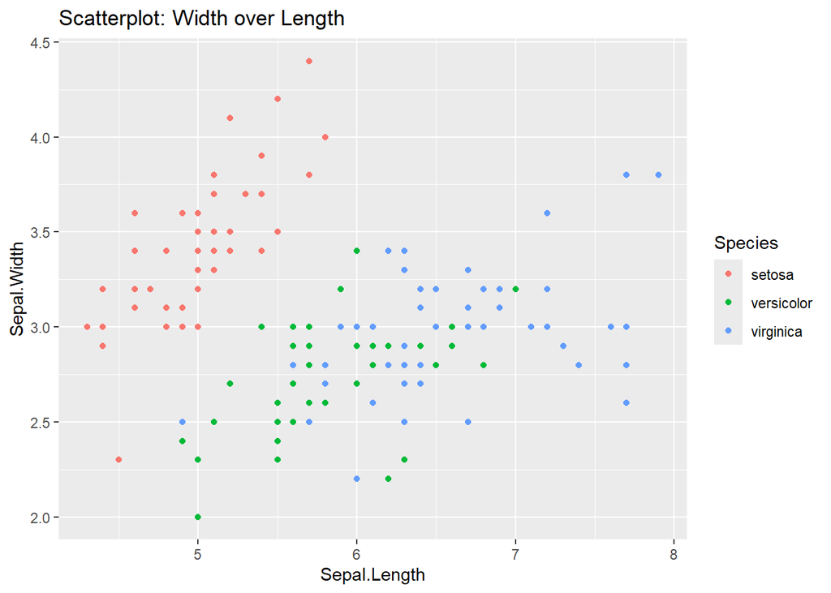

```r
ggplot(iris, aes(x = Sepal.Length, y = Sepal.Width, color = Species)) +
  ggtitle("Scatterplot: Width over Length") +
  geom_point()
```

## Scatterplot with regression lines

- add regression line for the previous plot with the whole dataset (regardless of the species)

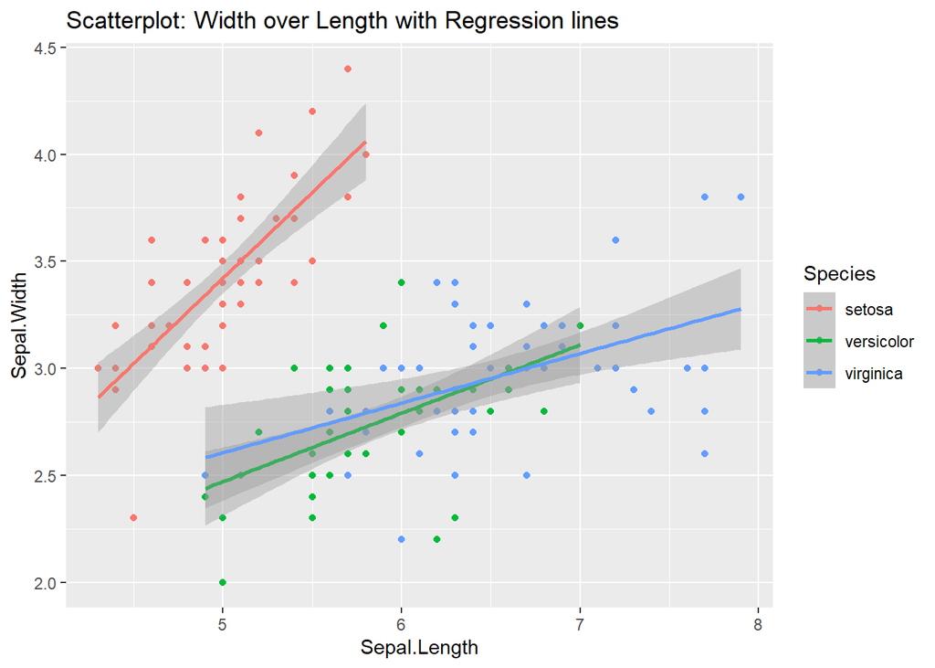

```r
ggplot(iris, aes(x = Sepal.Length, y = Sepal.Width, color = Species)) +
  ggtitle("Scatterplot: Width over Length with Regression lines") +
  geom_point() +
  geom_smooth(method = "lm")
```

## Pearson Correlation

- calculate the Pearson correlation for this plot

```r
cor.test(iris$Sepal.Width, iris$Sepal.Length,
         method = "pearson")
```

```
##
##  Pearson's product-moment correlation
##
## data:  iris$Sepal.Width and iris$Sepal.Length
## t = -1.4403, df = 148, p-value = 0.1519
## alternative hypothesis: true correlation is not equal to 0
## 95 percent confidence interval:
##  -0.27269325  0.04351158
## sample estimates:
##        cor
## -0.1175698
```

```r
# pearson is the default method, so that parameter is optional
```

## Box Plot

- make the boxplot for Petal.Width with 3 species separately in the x-axis in different colors

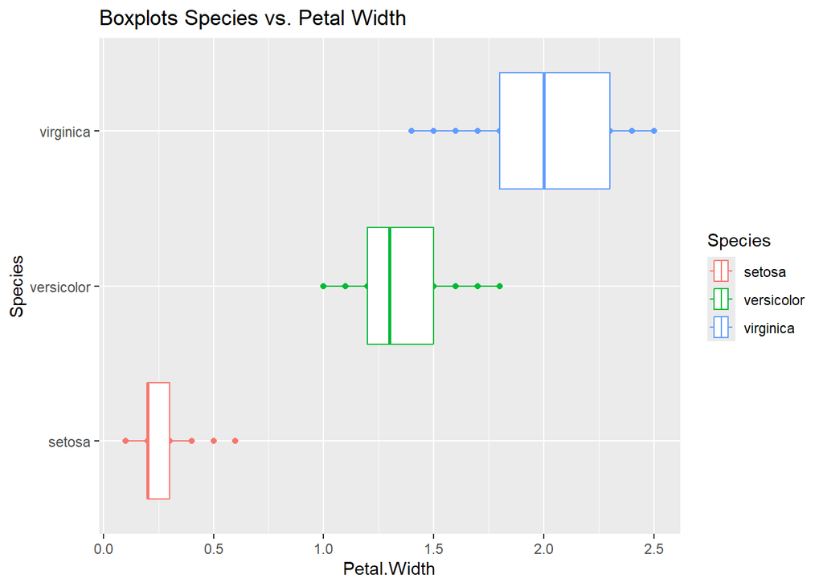

```r
ggplot(iris, aes(y = Species, x = Petal.Width, color = Species)) +
  ggtitle("Boxplots Species vs. Petal Width") +
  geom_point() +
  geom_boxplot()
```

## Histogram

- make the histogram for Petal.Width with 3 species separately in x-axis in different colors

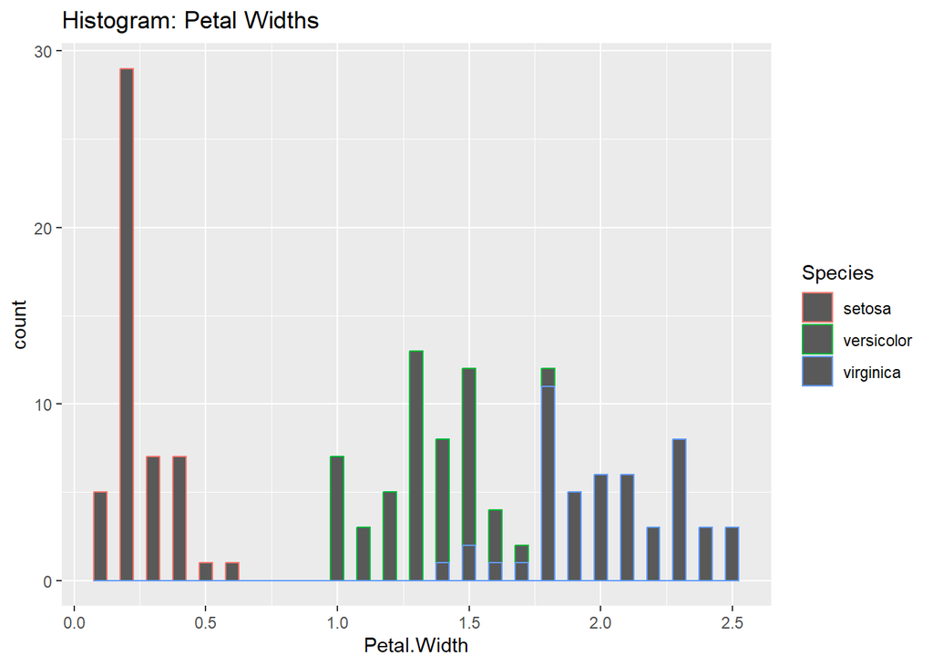

```r
ggplot(iris, aes(x = Petal.Width, color = Species)) +
  ggtitle("Histogram: Petal Widths") +
  geom_histogram(binwidth = 0.05)
```

## T-Test

- run the t-test of Petal.Width between setosa and virginica, and give the conclusion if the width is a statistically significant difference between 2 species

```r
t.test(Petal.Width ~ Species, data = iris,
       subset = Species %in% c("setosa", "virginica"))
```

```
##
##  Welch Two Sample t-test
##
## data:  Petal.Width by Species
## t = -42.786, df = 63.123, p-value < 2.2e-16
## alternative hypothesis: true difference in means between group setosa and group virginica is not equal to 0
## 95 percent confidence interval:
##  -1.863133 -1.696867
## sample estimates:
##    mean in group setosa mean in group virginica
##                   0.246                   2.026
```

### Conclusion

- The p-value of 0.00000000000000022 is far less than 0.05, so we can reject the null hypothesis, and conclude that the Petal.Width is a statistically significant difference between setosa and virginica
- This StackExchange answer proposes that that value is actually a placeholder for an even smaller value, output by R when the p-value is too small to be represented in floating point arithmetic: https://stats.stackexchange.com/a/403369

## Submission

4. knit to html
- You need to submit 2 files, one is the .Rmd file and the other is .html file
- The github/Gitlab link is acceptable as well.